# epitweetr: user documentation

### EARS as a Linear Model

We first observe that the above estimation of $\mu$ and $\sigma^2$ through $\overline{y}_0$ and $s_0^2$ at time 0 can be embedded within a linear regression model, i.e. for $i=1, \ldots, n$ we model
$$y_i = \mu + \epsilon_i, \quad\text{where}\quad \epsilon_t \stackrel{\text{iid}}{\sim} N(0, \sigma^2).$$
Note that we, for compatibility with the standard exposition in linear model theory, have indexed the $y$ values s.t. $y_{-n}$ corresponds to $y_1$ and $y_{-1}$ corresponds to $y_n$. In matrix terms let $\mathbf{y} = (y_{1},\ldots,y_n)'$ and for the intercept-only model the design matrix is $\mathbf{X} = (1,\ldots,1)'$, which has rank $k=1$. Thus from standard OLS theory:
$$\begin{align*}
\hat{\mu} &= (\mathbf{X}'\mathbf{X})^{-1} \mathbf{X}' \mathbf{y} = \frac{1}{n}\sum_{i=1}^n y_i,
\end{align*}$$
which corresponds to $\overline{y}_0$. Furthermore, let the raw residuals be defined as $e_i = y_i - \hat{\mu}$ for $i=1,\ldots, n$ and denote by $\mathbf{e}=(e_1,\ldots,e_n)'$ the corresponding vector of residuals. Then
$$\mathbf{e} = \mathbf{y} - \hat{\mathbf{y}} = \mathbf{y} - \mathbf{P} \mathbf{y} = (\mathbf{I}-\mathbf{P}) \mathbf{y}$$
where $\mathbf{P} = \mathbf{X} (\mathbf{X}'\mathbf{X})^{-1}\mathbf{X}'$ is the so called hat-matrix known from linear modelling. With this notation we can write up the estimate for $\sigma^2$ as in Chatterjee and Hadi (1988):

$$\hat{\sigma}^2 = \frac{\mathbf{e}' \mathbf{e}}{n-k} = \frac{\mathbf{y}'(\mathbf{I}-\mathbf{P})\mathbf{y}}{n-k} = \frac{1}{n-1} \sum_{t=-7}^1 (y_t - \hat{\mu})^2,$$
which corresponds to the above used expression for $s_0^2$.

### Downweighting

We now compute the so called **externally Studentized residuals** (Chatterjee and Hadi 1988)
$$r_i^* = \frac{e_i}{\hat{\sigma}_{(i)}\sqrt{1-p_{ii}}}, \quad i=1, \ldots, n,$$
where $p_{ii}$ is i’th diagonal element of the hat-matrix $\mathbf{P}$ from the corresponding linear model used above. Furthermore,
$$\hat{\sigma}_{(i)}^2 = \frac{\mathbf{y}_{(i)}' (\mathbf{I}-\mathbf{P}_{(i)}) \mathbf{y}_{(i)}}{n-k-1}$$
is the variance estimate obtained from a linear regression, where the i’th observation is removed. Linear modelling theory (Chatterjee and Hadi 1988) now states that
$$r_i^* \stackrel{\text{identical}}{\sim} t(n-k-1).$$
Note that the residuals are only identically distributed, because they are not independent (see Section 4.2.1. of Chatterjee and Hadi (1988) for details). However, the above distributional form allows us to assess for each historic value, if it can be considered as an outlier. For this purpose define $r_{\text{threshold}}$ as the $1-\alpha_{\text{outlier}}$ quantile of the t-distribution with $n-k-1$ degrees of freedom. A historic value is an outlier (for which one possible explanation is that it originates from a true increase in tweets, e.g. an outbreak situation), if $r_i^* > r_{\text{threshold}}$. We shall use this to formulate a weighting schemes for the historic values:

Downweight-Outliers:
$$\begin{align}
w^{(\text{dw})}_i &= \left\{
\begin{array}{ll}
1 & \text{if } r_i^* < r_{\text{threshold}}\\
\left(\frac{r_{\text{threshold}}}{(r_i^*)}\right)^k & \text{otherwise}
\end{array}
\right. \\
&= \min\left\{1,\left(\frac{r_{\text{threshold}}}{r_i^*}\right)^k\right\},
\end{align}$$
where the decay parameter $k>0$ is a known quantity. In the original Farrington et al. (1996) algorithm, $k=2$ was used. Furthermore, a threshold value of 1 was used. In the later Noufaily et al. (2013) paper, however, a threshold value of 2.58 was recommended. Note: both values are for the standardized Anscombe residuals, which follow a standard normal distribution. If we take corresponding quantiles for the t-distribution with 6 degrees of freedom the values would be 1.09 and 3.72. Note also that the term $(r_{\text{threshold}}/r_i^*)^k$ is a slight adaptation of Farrington et al. (1996), which instead uses $1/(r_i^*)^2$. The advantage of our proposal is that it ensures a smooth handling of values around the threshold if the threshold is not 1. It might be worth considering a higher power than 2 to ensure an even larger down-weighting for gross outliers. The current default value for the decay parameter in `epitweetr` is 4.

Finally, as in Farrington et al. (1996), we normalise the weights such that they yield a sum of $n$ by
$$w_i^* = n \times \frac{w_i}{\sum_{i=1}^n w_i}$$
and then re-fit the linear model with these weights. For this purpose define the weight matrix as $\mathbf{W} = \operatorname{diag}(w_1^*,\ldots,w_n^*)$. We can use a subsequent weighted least squares approach to find
$$\begin{align*}
\hat{\mu}_W &= (\mathbf{X}' \mathbf{W} \mathbf{X})^{-1} \mathbf{X}' \mathbf{W} \mathbf{y} = \frac{1}{n}\sum_{i=1}^n w_i^* y_i,
\end{align*}$$
where the 2nd equal sign is because $(\mathbf{X}' \mathbf{W} \mathbf{X})=\sum_{i=1}^n w_i=n$ and $\mathbf{X}' \mathbf{W} \mathbf{y} = \sum_{i=1}^n w_i^* y_i$. Furthermore,
$$s_W^2 =
\frac{\mathbf{y}'(\mathbf{I}-\mathbf{P}_W)\mathbf{y}}{n-k} =
\frac{\sum_{i=1}^n w_i^*(y_i - \mu_W)^2}{n-1},$$
where $P_W = \mathbf{X} (\mathbf{X}'\mathbf{W} \mathbf{X})^{-1}\mathbf{X}\mathbf{W}$ is the hat-matrix of the weighted least squares.

The downweighted procedure thus operates with $\mu_{W}$ and $s_W^2$ instead of $\overline{y}_0$ and $s_0^2$, respectively, when computing the upper limit $U_0$ using the above mentioned formula.

### Example of the downweighting approach using Ebola data

Fig 5: Upper limit with and without downweighting for the epitweetr Ebola data

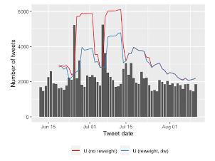

## Annex II: Troubleshooting and tips

This annex contains some tips and common solutions to errors or issues that `epitweetr` users may encounter, including an explanation on the checks included in the troubleshoot page.

In addition, you can also visit the [general post](https://github.com/EU-ECDC/epitweetr/discussions/7) in the discussion forum of the GitHub epitweetr repository for additional materials and training.

### The troubleshoot page

After running the diagnostics in the troubleshoot page, you can see the checks and status on the following aspects:

- **scheduler**: R package `taskscheduleR` is installed. Only applicable for Windows machines
- **twitter_auth**: Twitter token has been created after authenticating either with Twitter account or Twitter developer application
- **search_running**: search task is running
- **database_running**: embedded database is running
- **tweets**: tweets have been collected
- **os64**: R is 64bits
- **java**: Java is installed and accessible to epitweetr
- **java64**: Java 64bits is installed and accessible to epitweetr
- **java_version**: the Java version installed is compatible with `epitweetr`
- **winmsvc**: Microsoft Visual C++ 2010 SP1 Redistributable Package is installed. Only applicable for Windows machines
- **detect_activation**: detect loop has been activated
- **detection_running**: detection task is running
- **winutils**: winutils is installed. If false, it can be downloaded by running the update dependencies task. Only applicable for Windows machines
- **java_deps**: java dependencies are installed
- **move_from_temp**: `epitweetr` can atomically move files from temporary folder to data directory
- **tar_gz**: checks if tar.gz can be built, which is necessary for creating a compressed snapshot.
- **geonames**: Geonames.org database is downloaded and indexed
- **languages**: languages vectors are downloaded and indexed
- **aggregate**: aggregate task has successfully run
- **alerts**: alerts have been created
- **pandoc**: Pandoc is installed and accessible to `epitweetr`. Necessary for PDF creation.
- **tex**: a tex distribution is installed and accessible to `epitweetr`. Necessary for PDF creation.

### Management of epitweetr pipelines (‘epitweetr database’, ‘Data collection & processing’, ‘Requirements & alerts’) in Windows

After activating the three pipelines (‘epitweetr database’, ‘Data collection & processing’, ‘Requirements & alerts’) from the configuration page of `epitweetr` (Windows), three tasks will be created in the task scheduler and three terminal windows will be prompted. Please note that if the computer is logged/turned off or the terminal windows are closed, the pipelines will stop.

If you activate these tasks from the configuration page of `epitweetr` again, the system will overwrite the tasks created in the task scheduler. Instead, after the first successful activation of these tasks from `epitweetr`, you can easily manage these from the task scheduler. You can stop these tasks by ending and disabling the tasks in the task scheduler, and you can restart these tasks by enabling and running these in the task scheduler.

You can also force stopping these tasks in the configuration page of `epitweetr` by clicking on ‘stop’.

In the task scheduler, you can establish that the tasks “run whether the user is logged on or not” to avoid that these tasks stop when you log off or restart the computer. In this case, you may not see the prompted terminal windows when the tasks are running.

### Management of epitweetr pipelines (‘epitweetr database’, ‘Data collection & processing’, ‘Requirements & alerts’) in Linux and Mac

Since the three pipelines (‘epitweetr database’, ‘Data collection & processing’, ‘Requirements & alerts’) in Linux or Mac have to be run manually, if the computer is logged/turned off or the terminal windows are closed, the pipelines will stop. Please remember to follow the steps in the section *Setting up tweet collection and the alert detection loop* to run these tasks again.

The pipelines can be also stopped in the configuration page of `epitweetr` by clicking on ‘stop’.

### Running ‘epitweetr database’, ‘Data collection and processing’ and ‘Requirements and alerts’ pipelines

#### “Cannot execute task #####: the task is already running”

Each pipeline creates a file containing their process IDs located in the `epitweetr` data folder: fs.PID, search.PID and detect.PID. This error arises if `epitweetr` finds another R process currently running with the same ID. In order to fix this error, you should first verify if the pipelines are already running in another R session. If this is the case, you should not try to start the pipeline since `epitweetr` only supports one instance of the same pipeline running in the same machine. If the running process is not associated with the task, then you can manually delete the PID file and try to start it again.

#### “Failed while processing alerts”

The error “failed while processing alerts Error in do_next_alerts(tasks): Cannot determine the last aggregated period for alert detection. Please check that series have been aggregated” appears when there are no aggregated series to calculate the alerts. This can happen in the following cases: * No tweets have been collected in the past days so there were no tweets available to produce the aggregated series * Geonames and/or languages are not downloaded so the geolocation cannot be extracted from the tweets and, consequently, tweets cannot be aggregated.

If it is the first installation, you should wait until geonames and/or languages tasks are completed and collected tweets are geotagged and aggregated. Depending on the machine, these steps may take some hours.

You should also checked that tweets are being collected.

### Change the user of the Twitter authentication when using a Twitter account

1. End and disable the ‘Data collection & processing’ and ‘epitweetr database’ pipelines in the task scheduler (Windows), close the R/terminal window with the pipelines or forcing the pipelines in the configuration page (Windows, Linux and Mac)
2. Search for a file called “.rtweet_token” in hidden files. It is usually saved in the Documents folder.
3. Delete that file.
4. Click on “Update properties” in the configuration page of `epitweetr`.
5. Enable and run the pipelines in the task scheduler or active them in the configuration page (Windows), or run the command in a new R/terminal window with the pipelines (Windows, Linux and Mac). More details are available in the section *“Setting up tweet collection and the alert detection loop”*

### Downloading GeoNames and/or languages

#### Languages to be added or deleted

At least one language must be downloaded before adding new languages or deleting any of the default languages.

#### “The specified size exceeds the maximum representable size. Error: Could not create the Java Virtual Machine”

If this error appears when running GeoNames, it means that the machine has Java 32bits. You need to install Java 64bits. And make it accessible to epitwitter either by setting “JAVA_HOME” environment variable or by setting the right java binary on the system PATH.

### The “Launch slots” in the configuration page show NAs instead of the time slots

If it is the first time that you install and launch `epitweetr`, the geotag task of the detection pipeline has to be run at least once in order to see time slots in the “Launch slots” in the configuration page.

### Downloading PDF of the dashboard

#### “Error in: LaTeX failed to compile C:\Users\name~1\…\file######.tex.”

This error appears in Windows when clicking on “PDF” in the dashboard and no PDF is saved. The reason is that the path to TEMP and TMP environment variables of the user are too long, Windows shortens the path and `epitweetr` cannot find this new path. Please follow the next steps to fix this:

1. Open the “environment variable for your account”
2. Change the path for TEMP and TMP to a shorter path (e.g. “C:\Temp”). The same path should be used for both environment variables.
3. Log off and log on
4. You can now download and save the PDF from the dashboard

#### “Error: pandoc document conversion failed with error 6”

1. Downloading this script (https://raw.githubusercontent.com/jgm/pandoc/master/macos/uninstall-pandoc.pl)
2. Uninstall pandoc (https://pandoc.org/installing.html) by running perl uninstall-pandoc.pl

### Different totals in dashboard outputs

When counting the total tweets in the dashboard of the Shiny app or in the downloadable data, you might get differences in the total numbers of tweets between the three outputs. This might be due to the following reasons:

1. World (all) versus World (geolocated)
   - The default option for the regions in World (all), this means that also non-geolocated tweets are included in the trendline, but only geolocated tweets can be visualized in the maps and the most frequent words figure, therefore the overall total of tweets can differ between these outputs wen selecting World (all) or the empty default.
2. Country specific analysis
   - If you select only one country in the filters, the trendline will show all tweets for this country, but the map will show the tweets on a subnational level in the map. It could be that some tweets might have been geolocated to a certain country, but without further subnational data. These tweets will then be visible in the trendline total, but not in the subnational bubbles in the map.
3. Most frequent words/hashtags
   - In contrast to the other outputs in the dashboard, the most frequent words figure is always based on tweet location regardless of the filter (due to memory capacity). Therefore, if user location or both locations are selected in the location filter, this figure might have a different total then the other two outputs.

### Receiving only real-time alerts

This relates to users who have selected topics and/or regions for receiving related alerts in real-time or have selected topics and/or regions for receiving related alerts on a scheduled time span. If, in these cases, you only receive real-time alerts with all topics and regions, it may be that no time slots have been included in the subscribers file from the configuration page. These time slots are used for the scheduled alerts and if no slots are included in the file, alerts from all topics and regions are sent as real-time alerts.

### Not receiving email alerts

If you do not receive email alerts and you see an error in `epitweetr` referring to denied login, it means that `epitweetr` could not login to the email account provided in the configuration page. Some of the reasons for that are:

- The server or port included in the configuration page are incorrect
- The attempt of `epitweetr` to login to the email account is being blocked by the server. This can happen with some organisational email accounts. In that case, please contact the IT department of your organisation
- If using Gmail account, you need to allow less secure apps in the settings of your account

## References

Allévius, Benjamin, and Michael Höhle. 2017. “Prospective Detection of Outbreaks.” *arXiv:1711.08960 [Stat]*, November. https://arxiv.org/abs/1711.08960.

Chatterjee, Samprit, and Ali S. Hadi. 1988. *Sensitivity Analysis in Linear Regression*. Wiley Series in Probability and Mathematical Statistics. New York: Wiley.

Farrington, C. P., N. J. Andrews, A. D. Beale, and M. A. Catchpole. 1996. “A Statistical Algorithm for the Early Detection of Outbreaks of Infectious Disease.” *Journal of the Royal Statistical Society. Series A (Statistics in Society)* 159 (3): 547. https://doi.org/10.2307/2983331.

Fricker, Ronald D., Benjamin L. Hegler, and David A. Dunfee. 2008. “Comparing Syndromic Surveillance Detection Methods: EARS’ Versus a CUSUM-Based Methodology.” *Statistics in Medicine* 27 (17): 3407–29. https://doi.org/10.1002/sim.3197.

Noufaily, Angela, Doyo Enki, Paddy Farrington, Paul Garthwaite, Nick Andrews, and Andre Charlett. 2013. “An Improved Algorithm for Outbreak Detection in Multiple Surveillance Systems.” *Online Journal of Public Health Informatics* 5 (1): e148. https://www.ncbi.nlm.nih.gov/pmc/articles/PMC3692796/.

Salmon, Maëlle, Dirk Schumacher, and Michael Höhle. 2016. “Monitoring Count Time Series in *R* : Aberration Detection in Public Health Surveillance.” *Journal of Statistical Software* 70 (10). https://doi.org/10.18637/jss.v070.i10.